# Homework 4

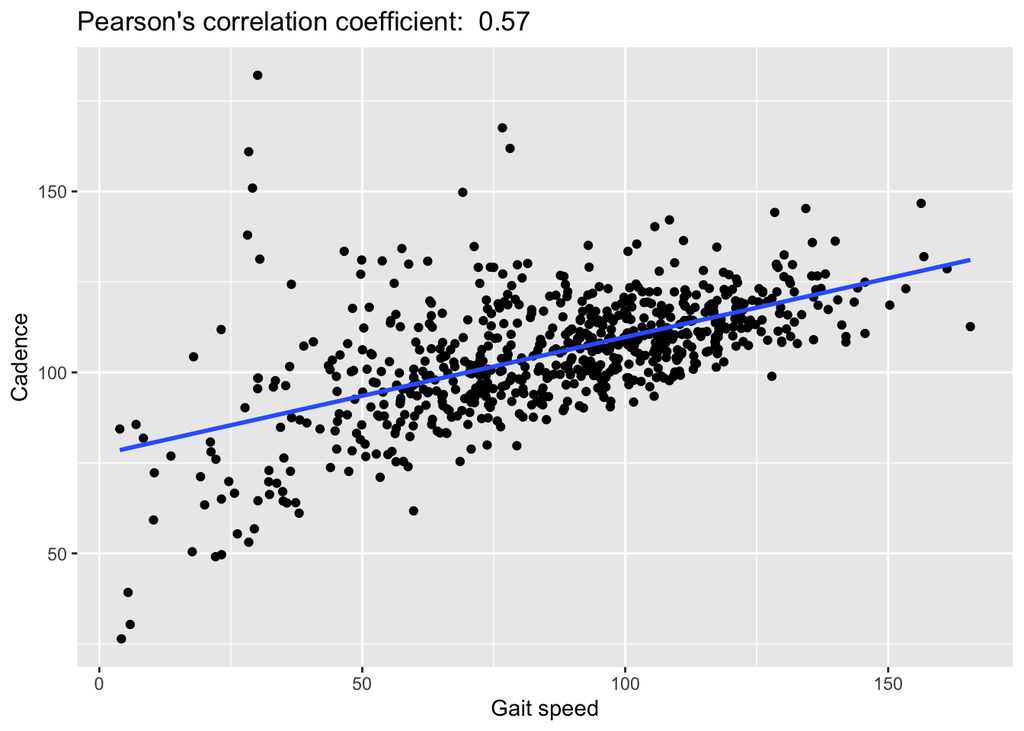

```r
#df_x <- data.frame(x_l <- redcap_without_na$speed, lab <- rep("gait speed", nrow(df_x)))

#df_y <- data.frame(x_l <- redcap_without_na$cadence, lab <- rep("cadence", nrow(df_y)))
#colnames(df_x) <- c("x_l", "lab")
#colnames(df_y) <- c("x_l", "lab")

#redcap_without_na_combined <- bind_rows(df_x,df_y)


ggplot(redcap_without_na, aes(x = speed, y = cadence)) +
geom_point() +
geom_smooth(method="lm", se=FALSE)+
ggtitle(paste("Pearson's correlation coefficient: ", round(correlation, 2))) +
xlab("Gait speed") +
ylab("Cadence")
```

9. We have not discussed (at least at length) joint frequency functions / probability mass functions, but they are a generalization of probability mass functions for a single random variable. Say the joint frequency function of two discrete random variables, X and Y, is as follows:

| X | Y=1 | Y=2 | Y=3 | Y=4 |
| --- | --- | --- | --- | --- |
| 1 | 0.10 | 0.05 | 0.02 | 0.02 |
| 2 | 0.05 | 0.20 | 0.05 | 0.02 |
| 3 | 0.02 | 0.05 | 0.20 | 0.04 |
| 4 | 0.02 | 0.02 | 0.04 | 0.10 |

These data are available at [https://jlucasmckay.bmi.emory.edu/global/bmi510/joint_frequency.csv] Columns 2 through 4 are named Y1, Y2, Y3, and Y4. Completely melt the data **(1/2 point)** and extract numerical values from the codes `Y1`, `Y2`, etc. **(1/2 point)**

```r
library(tidyr)
library(reshape2)


data <- read.csv("https://jlucasmckay.bmi.emory.edu/global/bmi510/joint_frequency.csv")
melted_data <- melt(data, id.vars="X")

print(melted_data$value)
```

```
##  [1] 0.10 0.05 0.02 0.02 0.05 0.20 0.05 0.02 0.02 0.05 0.20 0.04 0.02 0.02 0.04
## [16] 0.10
```

10. Find and plot the marginal frequency functions of X and Y. In the two-by-two table above, these would be the row and column sums. (The margins.) To what do the frequencies sum? **(1 point)**

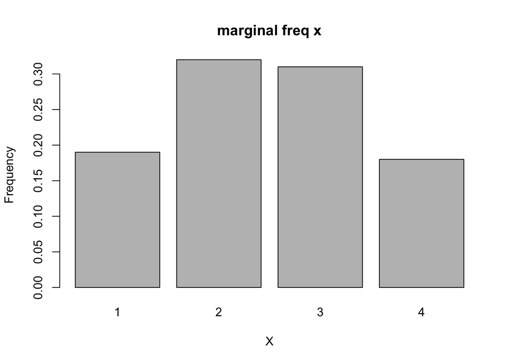

```r
marginal_frequency_X <- c(0.10 + 0.05 + 0.02 + 0.02,
                          0.05 + 0.20 + 0.05 + 0.02,
                          0.02 + 0.05 + 0.20 + 0.04,
                          0.02 + 0.02 + 0.04 + 0.10)

marginal_frequency_Y <- c(0.10 + 0.05 + 0.02 + 0.02,
                          0.05 + 0.20 + 0.05 + 0.02,
                          0.02 + 0.05 + 0.20 + 0.04,
                          0.02 + 0.02 + 0.04 + 0.10)

cat("Marg freq x:", marginal_frequency_X, "\nMarg freq y",marginal_frequency_Y)
## Marg freq x: 0.19 0.32 0.31 0.18
## Marg freq y 0.19 0.32 0.31 0.18

barplot(marginal_frequency_X, names.arg=c(1,2,3,4), xlab="X", ylab="Frequency", main = "marginal freq x")
```

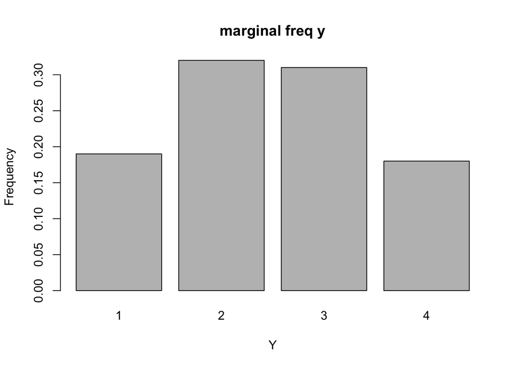

```r
barplot(marginal_frequency_Y, names.arg=c(1,2,3,4), xlab="Y", ylab="Frequency", main = "marginal freq y")
```

```r
#The frequencies represent the distribution of the discrete random variables X and Y. The sum of the marginal frequencies represent the total count of occurrences of X and Y.
```